# 第一篇 数据与分析

2014-11-20

## 大纲

- **数据**
- **分析**
- **方法**  
  数据越来越多，信息越来越深。  
  经验pk数据，分析无处不在，合理的值得存在。  
  没有最好的方法，只有最适合的方法。

*感谢*

[figure not shown]

[统计之都](http://cos.name/)  
[Rstudio](http://www.rstudio.com/)  
……

## 数据分析方法

- 数据量级
- 抽样分析
- 认识数据

[大数据的九点思考,刘德寰](http://www.emarketing.net.cn/magazine/adetail.jsp?aid=2381)

## 数据分析方法

- 数据量级  
  天气、地震、量子物理、基因等，都是大数据；  
  任何一个网站的数据都是人们互联网行为数据的很小的一个子集；  
  人们面对的是信息过载，有效信息筛选的问题；

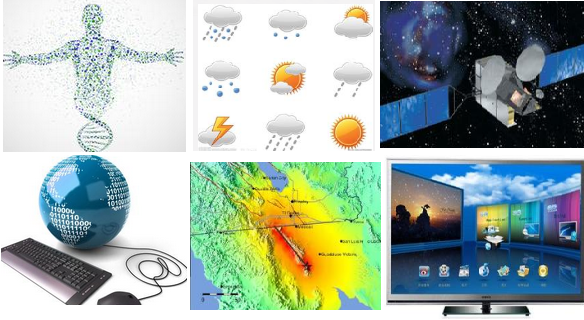

## 数据分析方法

- 抽样分析  
  数据量的大幅增加会造成结果的不准确，来源不同的信息混杂会加大数据的混乱程度；  
  抽样是简化问题，发现规律的有效方法之一；
- 美国大选  
  永久的课题，始于1936，盖洛普5万随机抽样vs《文学摘要》250万问卷，罗斯福vs蓝顿. （都是样本） 2012,538模型,Nate Silver.

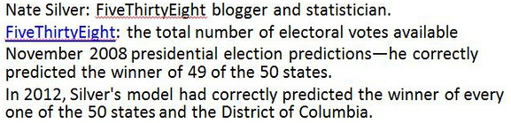

[538美国大选预测模型](http://site.douban.com/146782/widget/notes/15517178/note/321469585/)

## 数据分析方法

- 认识数据  
  ** 数据是不是客观的  
  ** 规律多样都靠谱么  
  ** 认识是主观的  
  ** 面对数据：从认识自己开始

## 数据分析方法

数据只有经过合理的分析，使用合适的方法，才可能得到较为符合实际的结论。  
然而，事实是，对于无处不在的数据，只要用上一种方法，就能得到一个结论。  
下面介绍几个分析角度，描述几个从客观数据到主观推断的风险。  
- 换个视角（圈圈图）  
- 相关性假象  
- 一步到位的分析  
- 辛普森悖论

## 数据分析方法

- 噪音大过信息，一团糟的数据中规律在哪儿

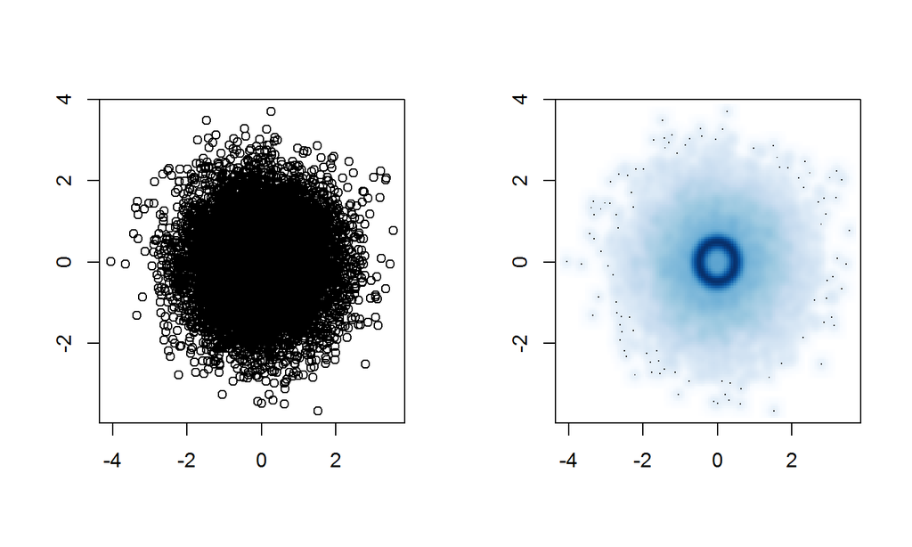

```r
par(mfrow = c(1, 2), ann = FALSE)
plot(BinormCircle)
smoothScatter(BinormCircle)
```

## 数据分析方法

一个简单的方法，改变下观察视角：点的大小+放大

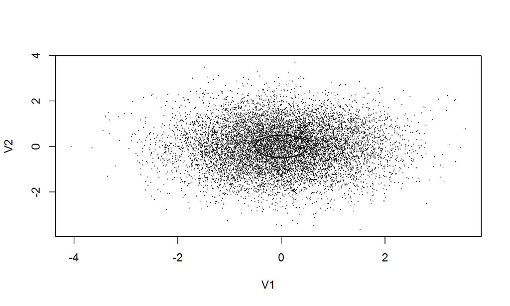

```r
par(mfrow = c(1, 1))
plot(BinormCircle,pch=19,cex=0.01)
```